# The Stability/Flexibility Tradeoff On Task-switching

Sophia Angleton, Fiona Debernardi, Stephen Anti

2024-12-11

## Abstract

This study is interested in understanding the relationship between task-switching and the cognitive stability-flexibility tradeoff. The design of this study will involve task-switching in an alternating runs manner, where there are two cues this task switches between, shape and color and these alternate in cycles of 4, each run being cycles of 4. This study will use alternating runs task-switching to understand the relationship between cognitive stability and cognitive flexibility. We will use the stability-flexibility tradeoff to inform our predictions, where we predict that 1) There is a negative relationship between expression of stability and expression of flexibility. We will see this relationship on three levels, within-subjects, in individual differences, and on the experimental level. Through a basic analysis of data, we saw there was a difference between stability and flexibility through a difference in switch cost measured in response time. This shows that there is a presence of stability and flexibility informing our task-switching study, however further analysis is required to understand the directionality of the relationship.

## Introduction

The paradigm between cognitive stability and cognitive flexibility is a widely known and established relationship in the world of cognitive science. Both cognitive stability and flexibility are aspects of executive functioning, or what we understand as self-control (Monsell and Driver 2000). Cognitive flexibility centers itself in a domain of executive functioning called mental set shifting, and in previous literature, has been understood through the use of the task-switching paradigm. Tasks such as odds-evens, the Stroop task, or other alternating tasks where through the use of cues, participants need to identify an alternating attribute of a stimuli (Mayr, Kuhns, and Hubbard 2014). For this study, the task-switch paradigm is constructed through the identification of one of two attributes, color or shape, where they identify color of the stimulus or shape of the stimulus, respectively. According to the established stability/flexibility tradeoff, when one is performing a task that requires more cognitive stability, it is harder to also be more cognitively flexible. This is seen in the task-switch paradigm within-subjects where they have less switch-costs when not switching task cues compared to higher switch-costs when switching from one cue to another (Mayr and Grätz 2024).

However, a recent reevaluation of the generalizability of the stability/flexibility tradeoff has posited that tradeoffs originally thought to explain a plethora of cognitive models, occur only in highly specified contexts (Mayr and Grätz 2024). Instead, there is newfound evidence of an anti-tradeoff pattern, meaning there is co-occurrence of cognitive stability and flexibility depending on the level of resolution encoding (Mayr and Grätz 2024). These recent findings in the field of decision-making suggest that the stability-flexibility trade off may not be as strong as once thought, however in this study we are still predicting we will see a negative relationship between the switch (flexibility) and no-switch (stability) variables through a comparison of error rate and response time until further studies explain more about a potential anti-tradeoff occurring. Indeed, using the stability-flexibility tradeoff to inform our predictions, we predict that: 1) There is a negative relationship between expression of stability and expression of flexibility. We will see this relationship on three levels, within-subjects, in individual differences, and on the experimental level. We will calculate the difference in reaction times between no-switch and switch trials. A smaller reaction time difference is interpreted as a higher level of stability, whereas a longer reaction time indicates a higher level of flexibility (Monsell and Driver 2000).

## Methods

### Data Cleaning

Using RStudio, the first major step for analyzing the dataset involved a clean-up process. The first clean up involved re-naming columns for better understanding of the dataset. Variables dim1 was replaced with dimshape, dim2 replaced with dimcolor, time replaced with RT, cor with correct, and res with response. Following from that, numeric values in the dataset were replaced with character strings for the variables Task and Error. Practice trials were then removed from the dataset since the ultimate for the final data is to isolate switch trials and control trials.

### Determine and remove outliers

#### Outliers by Error:

Since a key task of this study is to test for accuracy, it was necessary to operationalize accuracy by setting a criterion of 80% accuracy in all trials per participant. Out of the total of 896 trials, and using the 80% accuracy limit, at least 179 were needed to meet the accuracy threshold denoted by 0 in the error variable column. Grouping by id and summing by error and filtering out all those falling below the accuracy threshold, two people fellow below the accuracy threshold and were removed (id : 70 and id: 87). These two were the outliers by error.

### Outliers by inter-response

A close inspection of the data and examining RT variable in descending order, showed that some participants only did 7 blocks of runs instead of 8. To account for this variance, the z-score for each sequence position along with switch and ambiguity were run on the RT variable and Z-Score was also run on each block.

To arrive at this, the first step was to separate switch trials, c(1,5) and control trials !c(1,5). This means, if task is 1 or 5, we assigned switch, else, it was assigned as control. First trial after each block had to be thrown out because it is not a switch or noswitch. Cycle positions were separated into cycle positions of 4, making a total of 16 conditions.

## Mean and Standard Error of Response Time

Outliers were identified for z-scores ( scores beyond -3 and 3), means and standard error of response time for each trail type was also calculated.

## Results

First, we created a density plot to examine how response times (RT) were distributed in the data set (See Figure 1). We wanted to first examine how participants were responding across all conditions, so we averaged participants response times and then put them into this density plot. The average response times (as indicated by the red dashed line) was 860.44 ms, and the standard deviation was 697.28 ms.

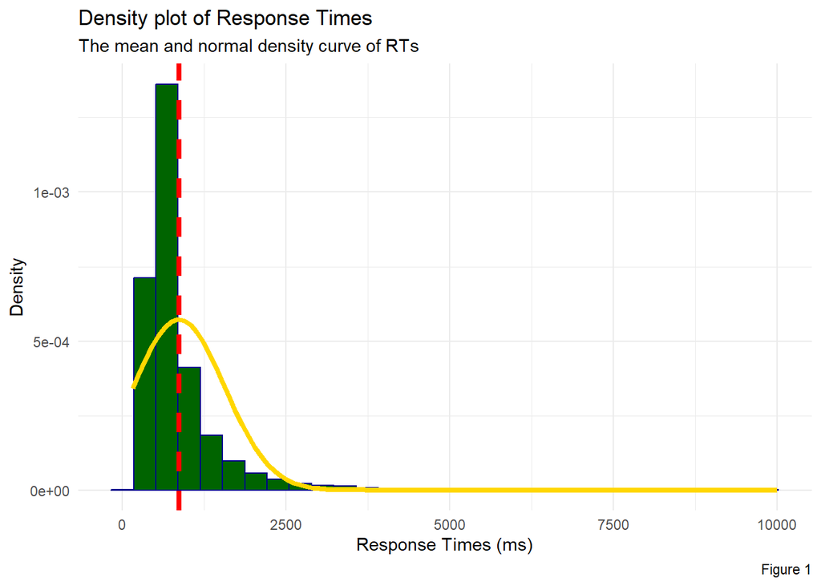

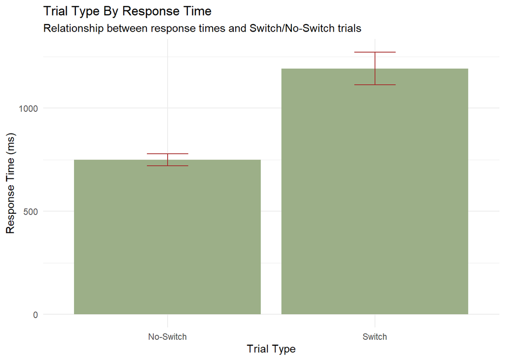

## References

Mayr, Ulrich, and Dominik Grätz. 2024. “Does Cognitive Control Have a General Stability/Flexibility Tradeoff Problem?” *Current Opinion in Behavioral Sciences* 57 (June): 101389. https://doi.org/10.1016/j.cobeha.2024.101389.

Mayr, Ulrich, David Kuhns, and Jason Hubbard. 2014. “Long-Term Memory and the Control of Attentional Control.” *Cognitive Psychology* 72 (July): 1–26. https://doi.org/10.1016/j.cogpsych.2014.02.001.

Monsell, Stephen, and Jon Driver. 2000. *Control of Cognitive Processes: Attention and Performance XVIII*. The MIT Press. https://doi.org/10.7551/mitpress/1481.001.0001.